# Chapter 3 - Applied Exercises

ZackBarry

6/24/2019

## Chapter 3 Exercises

#### 8. This question involves the use of simple linear regression on the Auto data set.

```r
simple_lm <- lm(mpg ~ horsepower, data = Auto)
summary(simple_lm)
```

```
##
## Call:
## lm(formula = mpg ~ horsepower, data = Auto)
##
## Residuals:
##      Min       1Q   Median       3Q      Max
## -13.5710  -3.2592  -0.3435   2.7630  16.9240
##
## Coefficients:
##              Estimate Std. Error t value Pr(>|t|)
## (Intercept) 39.935861   0.717499   55.66   <2e-16 ***
## horsepower  -0.157845   0.006446  -24.49   <2e-16 ***
## ---
## Signif. codes:  0 '***' 0.001 '**' 0.01 '*' 0.05 '.' 0.1 ' ' 1
##
## Residual standard error: 4.906 on 390 degrees of freedom
## Multiple R-squared:  0.6059, Adjusted R-squared:  0.6049
## F-statistic: 599.7 on 1 and 390 DF,  p-value: < 2.2e-16
```

1. Since the p-value is close to zero, this indicates that the null hypothesis can be rejected. The alternative hypothesis when fitting a linear model is that there is a relationship between the predictor and the response.
2. Two variables `u` and `v` are said to have a strong relationship if, given a certain value of `u` we can predict `v` with a high level of accuracy. Recall that RSE, residual standard error, can be interpreted as the average amount that the response will deviate from the true regression line. For the above model, RSE = 4.906 and the average response value is 23.45 — the predicted response will have an average error of 20.92%. This indicates that we can predict mpg with decent accuracy given horsepower — the two variables have a strong relationship. As another piece of evidence, recall that R-squared measures the proportion of variability in the response that can be explained using the predictor. For the above model, 60.59% of the variability in mpg can be explained by horsepower. This indicates that the two have a strong relationship, but that there is likely another predictor variable that could improve the model.
3. The relationship between horsepower and mpg is negative since the estimate of the coefficient on horsepower is negative. It is important to also note that the standard error of the horsepower coefficient is so small that the 95% confidence interval around it, (-0.15 - 2 * 0.006, - 0.15 + 2 * 0.006), only contains negative values.
4. The predicted `mpg` associated with a `horsepower` of 98, along with confidence and prediction intervals are found below:

```r
predict(simple_lm, data.frame(horsepower = 98), interval = "confidence")
```

```
##        fit      lwr      upr
## 1 24.46708 23.97308 24.96108
```

```r
predict(simple_lm, data.frame(horsepower = 98), interval = "prediction")
```

```
##        fit     lwr      upr
## 1 24.46708 14.8094 34.12476
```

2. Plot the response and the predictor along with the least squares regression line.

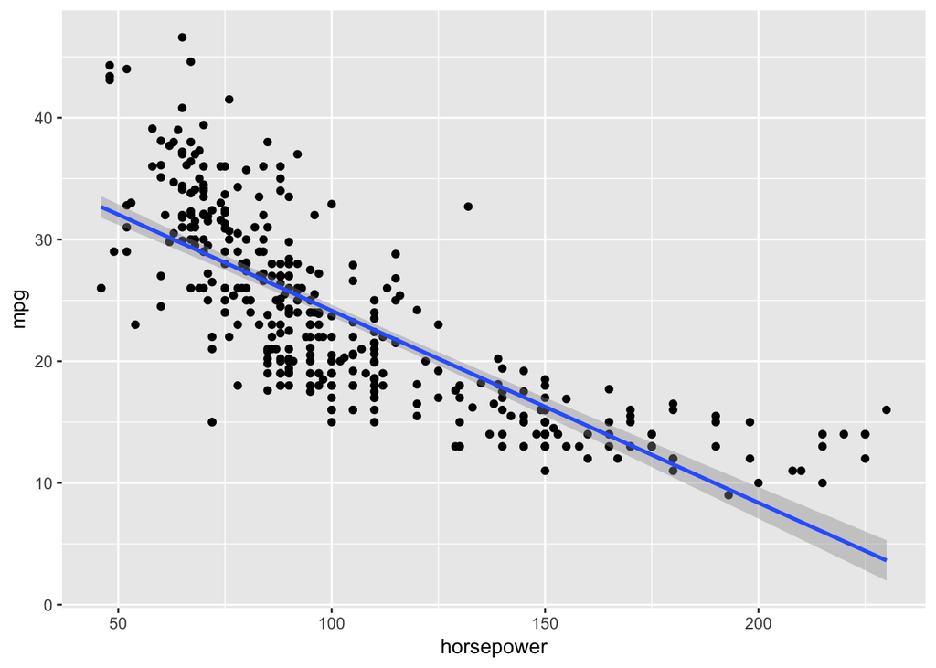

```r
ggplot(data = Auto, aes(x = horsepower, y = mpg)) +
  geom_point() +
  stat_smooth(method = "lm")
```

3. Use the `plot()` function to produce diagnostic plots of the least squares regression fit. Comment on any problems you see with the fit.

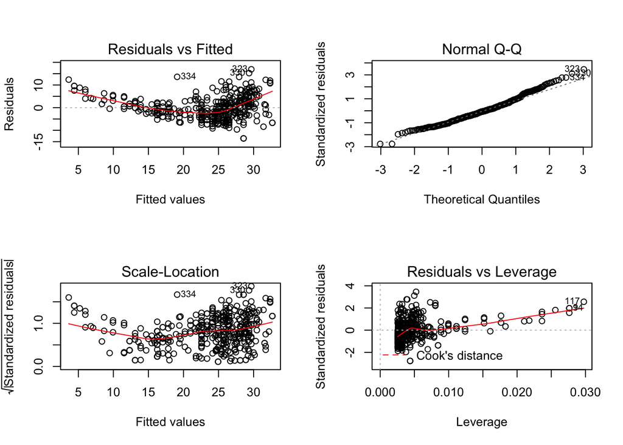

```r
par(mfrow = c(2,2))
plot(simple_lm)
```

```r
par(mfrow = c(1,1))
```

Notice that the values of the residuals are not uncorrelated with the fitted values. This indicates that the assumption that the relationship is best described as linear is incorrect.